# Advance Bioinformatics 2025 Assignment

Hanae Roussotte - AF52866

2025-04-18

# *Part 1: R Assignment*

## Task 3.1.

The colon operator (:) creates a sequence from 5 to 55, and sum() adds all numbers in this sequence.

```r
# Calculate the sum of integers from 5 to 55
sum(5:55)
```

```
## [1] 1530
```

## Task 3.2.

I created a function sumfun that takes parameter n and calculates the sum of integers from 5 to n using the same approach as in Task 3.1.

```r
# Function to calculate sum of integers from 5 to n
sumfun <- function(n) {
  return(sum(5:n))
}

# Test with different values of n
sumfun(10)
```

```
## [1] 45
```

```r
sumfun(20)
```

```
## [1] 200
```

```r
sumfun(100)
```

```
## [1] 5040
```

## Task 3.3.

I initialised an array to hold 12 Fibonacci numbers, set the first two values to 1, then used a for loop to calculate each subsequent value as the sum of the two preceding numbers.

```r
# Calculate first 12 entries of Fibonacci sequence
fibonacci <- numeric(12)
fibonacci[1] <- 1
fibonacci[2] <- 1

for (i in 3:12) {
  fibonacci[i] <- fibonacci[i-1] + fibonacci[i-2]
}

fibonacci
```

```
##  [1]   1   1   2   3   5   8  13  21  34  55  89 144
```

```r
#Installing useful libraries
library(dplyr)
```

```r
library(pheatmap)
library(tidyverse)
```

## Task 3.4.

I used the ggplot2 library to create a boxplot of mpg (miles per gallon) grouped by the number of gears, with each gear category filled with a different color.

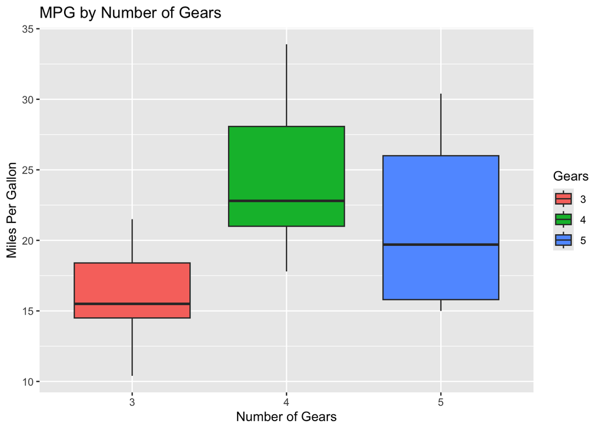

```r
# Load required library
library(ggplot2)

# Create boxplot of mpg by number of gears
ggplot(mtcars, aes(x = as.factor(gear), y = mpg, fill = as.factor(gear))) +
  geom_boxplot() +
  labs(x = "Number of Gears", y = "Miles Per Gallon",
       title = "MPG by Number of Gears") +
  scale_fill_discrete(name = "Gears")
```

## Task 3.5.

I used the lm function to fit a linear regression model, with stopping distance as the dependent variable and speed as the independent variable.

```r
# Fit linear model of distance vs speed
?cars
cars_model <- lm(dist ~ speed, data = cars)
summary(cars_model)
```

```
##
## Call:
## lm(formula = dist ~ speed, data = cars)
##
## Residuals:
##     Min      1Q  Median      3Q     Max
## -29.069  -9.525  -2.272   9.215  43.201
##
## Coefficients:
##             Estimate Std. Error t value Pr(>|t|)
## (Intercept) -17.5791     6.7584  -2.601   0.0123 *
## speed         3.9324     0.4155   9.464 1.49e-12 ***
## ---
## Signif. codes:  0 '***' 0.001 '**' 0.01 '*' 0.05 '.' 0.1 ' ' 1
##
## Residual standard error: 15.38 on 48 degrees of freedom
## Multiple R-squared:  0.6511, Adjusted R-squared:  0.6438
## F-statistic: 89.57 on 1 and 48 DF,  p-value: 1.49e-12
```

The summary output shows the coefficient estimates and their standard errors : * the intercept (-17.5791, SE : 6.7584) would be be the theoretical braking distance distance when the car’s speed is zero (eventhough practically a negative braking distance doesn’t have a real-world meaning and would suggest the model has limitations at low speed) * the slope (3.9324, SE ; 0.4155) indicates that for every additional mile per hour increase in speed, the braking distance increases by approximately 3.93 feet.

Looking at the cars help page, the units in the dataset are: * speed: miles per hour * distance: feet

## Task 3.6.

I plotted the speed vs. distance data points with a fitted linear regression line using the ggplot2 library.

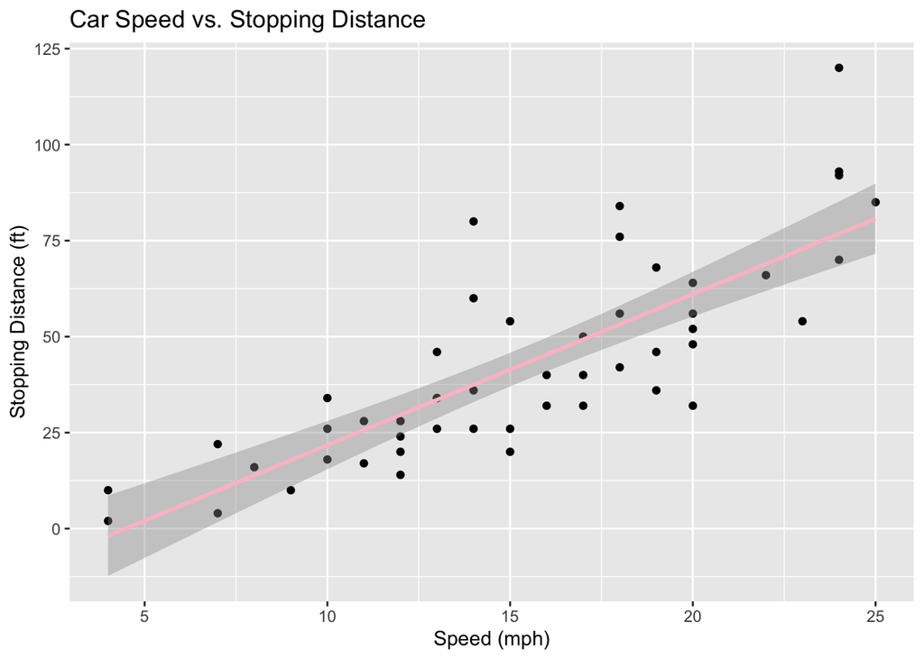

```r
# Plot data points and linear fit
ggplot(cars, aes(x = speed, y = dist)) +
  geom_point() +
  geom_smooth(method = "lm", col = "pink") +
  labs(x = "Speed (mph)", y = "Stopping Distance (ft)",
       title = "Car Speed vs. Stopping Distance")
```

## Task 3.7.

- I created a new variable for speed squared, assuming breaking distance is proportional to the square of speed
- Fitted a linear model without intercept for breaking distance
- Calculated the reaction time by finding the difference between total stopping distance and the predicted breaking distance, then dividing by speed (!!converted to feet per second)
- Plotted the data with the fitted quadratic curve

```r
# Assuming breaking distance is proportional to speed^2
# Create new dataframe with speed^2
cars_squared <- cars
cars_squared$speed_squared <- cars$speed^2

# Fit linear model with no intercept (distance ~ speed^2)
# The -1 tells R to fit the model without intercept :
# when car has zero speed, it should have 0 braking distance
cars_model_squared <- lm(dist ~ speed_squared - 1, data = cars_squared)
summary(cars_model_squared)
```

```
##
## Call:
## lm(formula = dist ~ speed_squared - 1, data = cars_squared)
##
## Residuals:
##     Min      1Q  Median      3Q     Max
## -29.350  -7.988   1.325   8.080  49.939
##
## Coefficients:
##               Estimate Std. Error t value Pr(>|t|)
## speed_squared 0.153374   0.007122   21.54   <2e-16 ***
## ---
## Signif. codes:  0 '***' 0.001 '**' 0.01 '*' 0.05 '.' 0.1 ' ' 1
##
## Residual standard error: 15.61 on 49 degrees of freedom
## Multiple R-squared:  0.9044, Adjusted R-squared:  0.9025
## F-statistic: 463.8 on 1 and 49 DF,  p-value: < 2.2e-16
```

```r
# Calculate reaction time
coefficient <- coef(cars_model_squared)["speed_squared"]
# Reaction time (sec) = (total distance - breaking distance) / speed
# Breaking distance = coefficient * speed^2
# !Important! We need to convert speed from mph to feet per second
mph_to_fps <- 5280/3600  # 1 mph = 5280 ft/3600 sec = 1.467 fps

# Create a dataframe for plotting
plot_data <- data.frame(
  speed = cars$speed,
  dist = cars$dist,
  reaction_dist = cars$dist - coefficient * cars$speed^2
)

# Calculate average reaction time in seconds
reaction_time <- mean(plot_data$reaction_dist / (plot_data$speed * mph_to_fps))
cat("Estimated average reaction time:", reaction_time, "seconds\n")
```

```
## Estimated average reaction time: 0.1844593 seconds
```

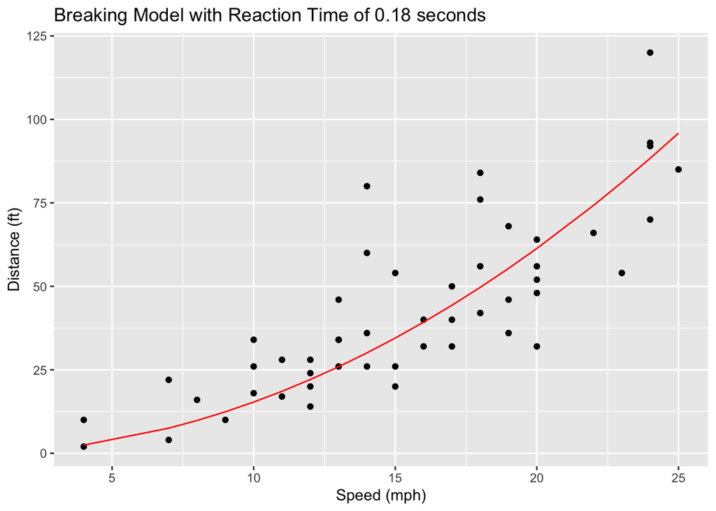

```r
# Plot data and model
ggplot(cars) +
  geom_point(aes(x = speed, y = dist)) +
  geom_line(aes(x = speed, y = coefficient * speed^2), color = "red") +
  labs(x = "Speed (mph)", y = "Distance (ft)",
       title = paste("Breaking Model with Reaction Time of", round(reaction_time, 2), "seconds"))
```

# *Part 2 : RNA-seq Assessment*

In this part, we will analyse the RNASeq data used in the RNA-seq tutorial to: * create a DESeq2 object, * normalize RNA-seq data with DESeq2, * perform differential Expression analysis with DESeq2, * visualize RNA-seq data using SDM and PCA methods.

## Task 3.8

This code reads in the RNA-seq count matrix and sample metadata. Setting row names for both datasets is crucial for proper alignment of samples. The count matrix has genes as rows and samples as columns, while the sample information has samples as rows with metadata columns.

```r
# Reading the count data
counts_data <- read.csv("LMS_RNAseq_short-master-2023-final/course/exercises/data/exercise1_counts.csv", row.names = 1)
head(counts_data)
```

```
##           control_FFa1.bam control_FFa2.bam control_FFa3.bam mutant_KOa1.bam
## 497097                  16               16                0              21
## 100503874               20                0                0              64
## 100038431                0                0                2               0
## 19888                   11                0               10             113
## 20671                   14               16                0              40
## 27395                  465              193              596             436
##           mutant_KOa2.bam mutant_KOa3.bam mutant_KOb1.bam mutant_KOb2.bam
## 497097                 16              27              20               0
## 100503874               0               4               5               0
## 100038431               0               8               0               0
## 19888                   0              26              14               6
## 20671                   8              33              33              12
## 27395                 686             572            1378            1901
##           mutant_KOb3.bam
## 497097                  2
## 100503874               2
## 100038431               0
## 19888                  16
## 20671                  24
## 27395                1553
```

```r
# Reading the sample description file - important to specify tab separator
sample_info <- read.delim("LMS_RNAseq_short-master-2023-final/course/exercises/data/exercise1_sample_description.info", sep="\t", header=TRUE)
head(sample_info)
```

```
##              filename sample condition batch
## 1    control_FFa1.bam   FFa1       FFa     a
## 2    control_FFa2.bam   FFa2       FFa     b
## 3    control_FFa3.bam   FFa3       FFa     c
## 4 TMC_mutant_KOa1.bam   KOa1       KOa     a
## 5 TMC_mutant_KOa2.bam   KOa2       KOa     b
## 6 TMC_mutant_KOa3.bam   KOa3       KOa     c
```

## Task 3.9

```r
# Create col_data and check dimensions
# Fix the mismatch between sample_info filenames and count data column names
# Remove the "TMC_" prefix from the mutant sample filenames in sample_info
sample_info$filename_fixed <- gsub("TMC_", "", sample_info$filename)
print(data.frame(original = sample_info$filename, fixed = sample_info$filename_fixed))
```

```
##              original            fixed
## 1    control_FFa1.bam control_FFa1.bam
## 2    control_FFa2.bam control_FFa2.bam
## 3    control_FFa3.bam control_FFa3.bam
## 4 TMC_mutant_KOa1.bam  mutant_KOa1.bam
## 5 TMC_mutant_KOa2.bam  mutant_KOa2.bam
## 6 TMC_mutant_KOa3.bam  mutant_KOa3.bam
## 7 TMC_mutant_KOb1.bam  mutant_KOb1.bam
## 8 TMC_mutant_KOb2.bam  mutant_KOb2.bam
## 9 TMC_mutant_KOb3.bam  mutant_KOb3.bam
```

```r
# Check if the fixed filenames match the column names
sample_matches <- colnames(counts_data) %in% sample_info$filename_fixed
print(paste("Do all column names match fixed filenames?", all(sample_matches)))
```

```
## [1] "Do all column names match fixed filenames? TRUE"
```

```r
# Create colData with the correct structure for DESeq2
colData <- data.frame(
  sample = sample_info$sample,
  condition = sample_info$condition,
  batch = sample_info$batch
)
rownames(colData) <- sample_info$filename_fixed
colData <- colData[colnames(counts_data),]

# Check dimensions
dim(counts_data)  # genes x samples
```

```
## [1] 26301     9
```

```r
dim(colData)
```

```
## [1] 9 3
```

## Task 3.10.

```r
# Construct DESeqDataSet object
# Convert condition to factor
colData$condition <- factor(colData$condition)
print("Condition levels:")
```

```
## [1] "Condition levels:"
```

```r
print(levels(colData$condition))
```

```
## [1] "FFa" "KOa" "KOb"
```

```r
# Create DESeqDataSet object
dds <- DESeqDataSetFromMatrix(
  countData = counts_data,
  colData = colData,
  design = ~ condition
)
```

## Task 3.11.

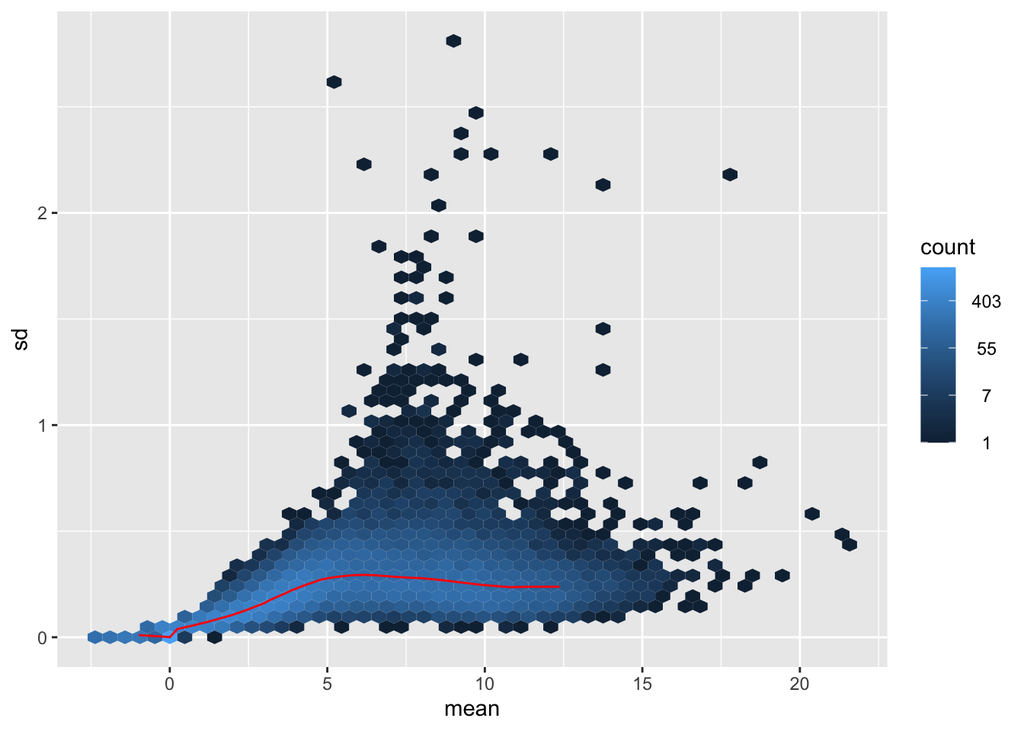

```r
# First, estimate size factors
dds <- estimateSizeFactors(dds)

# Perform rlog transformation
rld <- rlog(dds)

# Perform VST transformation
vst <- varianceStabilizingTransformation(dds)

# Check if transformations worked as expected using mean-SD plots
meanSdPlot(assay(rld), ranks=FALSE)
```

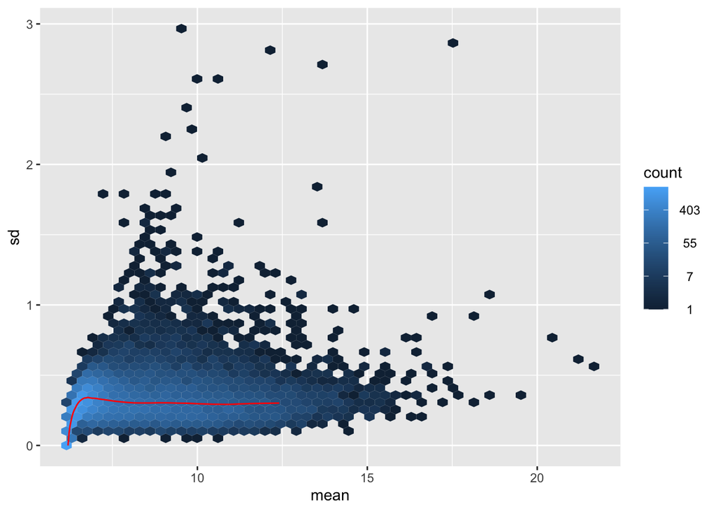

```r
meanSdPlot(assay(vst), ranks=FALSE)
```

Both transformations address the heteroskedasticity inherent in RNA-seq data, where higher expressed genes naturally show higher variance. By stabilising the variance, these transformations enable accurate downstream analyses including clustering, heatmaps, and PCA. The mean-SD plots confirm the effectiveness of both transformations, as the red trend line remains relatively flat and close to zero across expression levels, especially for the VST transformation (Image 2), indicating successful variance stabilization compared to untransformed data which would show a strong positive correlation between mean and standard deviation. The transformed data maintains biological signal while minimising technical variation, providing normalised data suitable for visualisation and exploration.

## Task 3.12.

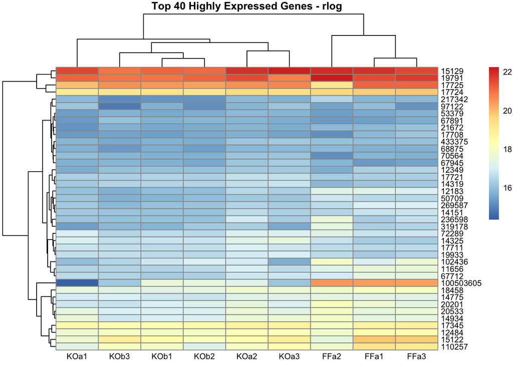

```r
library(pheatmap)
library(DESeq2)
library(matrixStats)  # for rowMeans()

# Select top 40 most highly expressed genes (based on rlog-transformed counts)
select <- order(rowMeans(assay(rld)), decreasing = TRUE)[1:40]

# Extract simplified sample names
sample_names <- colnames(assay(rld))
short_names <- gsub("(control_|mutant_|\\.bam)", "", sample_names)

# Heatmap for rlog transformation
pheatmap(
  assay(rld)[select, ],
  labels_col = short_names,
  main = "Top 40 Highly Expressed Genes - rlog",
  fontsize = 8,
  angle_col = 0
)
```

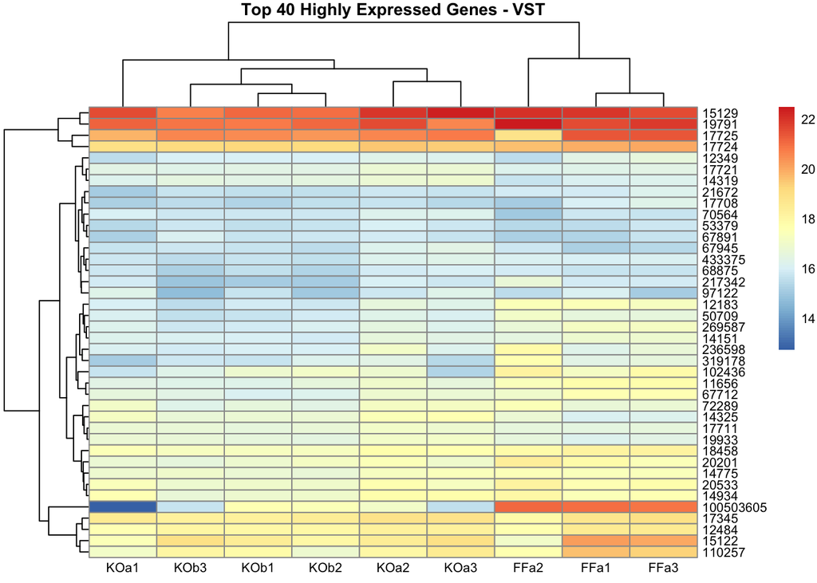

```r
# Heatmap for VST transformation
pheatmap(
  assay(vst)[select, ],
  labels_col = short_names,
  main = "Top 40 Highly Expressed Genes - VST",
  fontsize = 8,
  angle_col = 0
)
```

## Task 3.13.

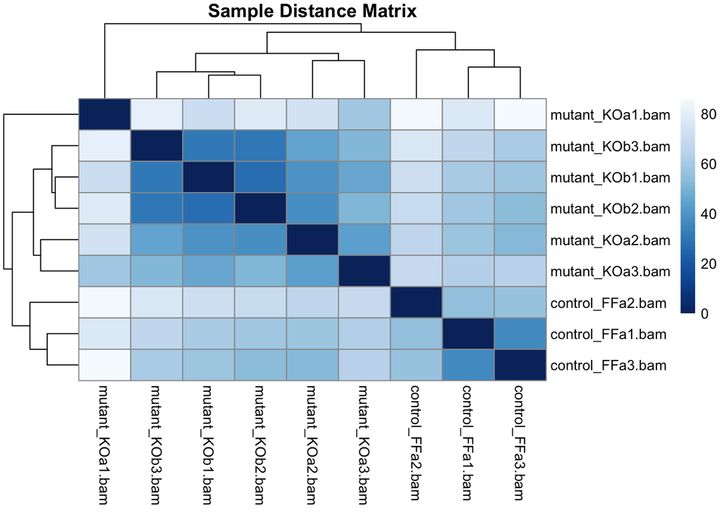

```r
library(RColorBrewer)

# Calculate sample distances
sampleDists <- dist(t(assay(rld)))
sampleDistMatrix <- as.matrix(sampleDists)

# Create distance heatmap
colors <- colorRampPalette(rev(brewer.pal(9, "Blues")))(255)
pheatmap(sampleDistMatrix,
         clustering_distance_rows=sampleDists,
         clustering_distance_cols=sampleDists,
         col=colors,
         main="Sample Distance Matrix")
```

This pattern aligns with what we observed in our earlier analyses - there is a strong separation between our experimental conditions while showing some interesting variability within the KOa group. This could reflect biological differences in how these particular samples responded to treatment, or might point to some technical variation worth investigating further.

## Task 3.14.

```r
# Perform PCA using rlog-transformed data
rlog_pca <- plotPCA(rld, intgroup = "condition", returnData = TRUE)
```

```
## using ntop=500 top features by variance
```

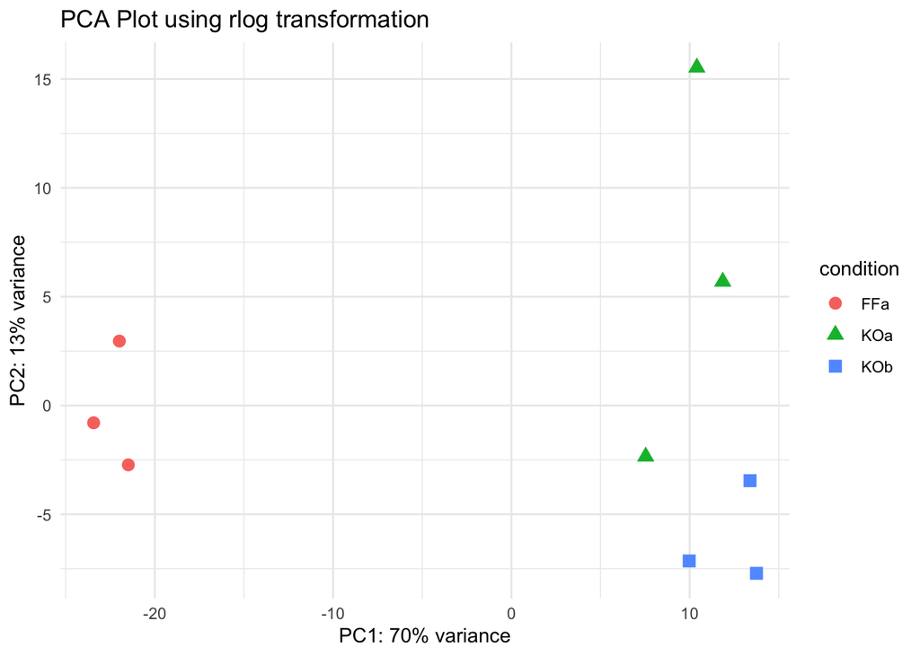

```r
# Extract % of variance explained by PC1 and PC2
percentVar_rlog <- round(100 * attr(rlog_pca, "percentVar"))

# Plot PCA
ggplot(rlog_pca, aes(PC1, PC2, color = condition, shape = condition)) +
  geom_point(size = 3) +
  xlab(paste0("PC1: ", percentVar_rlog[1], "% variance")) +
  ylab(paste0("PC2: ", percentVar_rlog[2], "% variance")) +
  ggtitle("PCA Plot using rlog transformation") +
  theme_minimal()
```

```r
# Print variance explained
cat("Percentage variance explained (rlog PCA):\n")
```

```
## Percentage variance explained (rlog PCA):
```

```r
cat(" - PC1:", percentVar_rlog[1], "%\n")
```

```
##  - PC1: 70 %
```

```r
cat(" - PC2:", percentVar_rlog[2], "%\n")
```

```
##  - PC2: 13 %
```

The PCA results provide a powerful visualisation of our dataset’s overall structure. Looking at the plot, we can see that PC1 captures a substantial 70% of the total variance, with PC2 accounting for another 13%. This tells us that the primary differences between samples are well-represented in just these two dimensions.

The control (FFa) and KOb samples form tight clusters in the PCA space, showing great consistency between replicates within these groups. This tight clustering suggests high-quality data with minimal technical variation for these conditions.

The KOa samples, however, are more spread out across the plot, confirming the pattern we observed in our distance matrix and heatmap. This increased variability within the KOa group could reflect true biological differences in how these samples responded to treatment, or might indicate some technical factors affecting these particular samples.

Overall, the PCA reinforces our understanding of the dataset structure, showing clear separation between experimental conditions while highlighting the interesting variability within the KOa group that might warrant further investigation.

```r
# PCA using VST transformation
vst_pca <- plotPCA(vst, intgroup = "condition", returnData = TRUE)
```

```
## using ntop=500 top features by variance
```

```r
percentVar_vst <- round(100 * attr(vst_pca, "percentVar"))

# PCA using rlog transformation (if not done earlier)
rlog_pca <- plotPCA(rld, intgroup = "condition", returnData = TRUE)
```

```
## using ntop=500 top features by variance
```

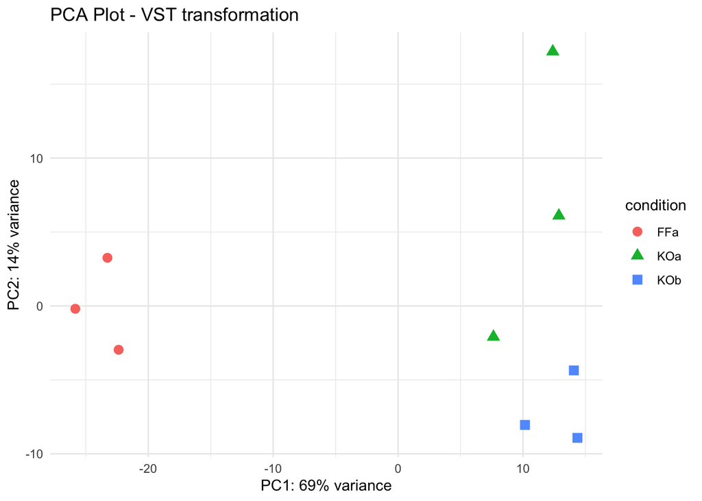

```r
percentVar_rlog <- round(100 * attr(rlog_pca, "percentVar"))

# Plot VST PCA
ggplot(vst_pca, aes(PC1, PC2, color = condition, shape = condition)) +
  geom_point(size = 3) +
  xlab(paste0("PC1: ", percentVar_vst[1], "% variance")) +
  ylab(paste0("PC2: ", percentVar_vst[2], "% variance")) +
  ggtitle("PCA Plot - VST transformation") +
  theme_minimal()
```

The VST-based PCA closely mirrors our rlog results, with PC1 and PC2 explaining similar proportions of variance (69% and 14%). The consistent clustering patterns across both transformations strengthen our confidence that we’re capturing real biological effects rather than technical artifacts. While rlog provides slightly better separation along PC1 (70% vs 69%), VST shows marginally improved resolution on PC2 (14% vs 13%), suggesting the two methods have comparable performance for our dataset.

FFa and KOb samples again form tight clusters, while KOa samples remain more dispersed regardless of the normalization method. This consistency confirms two important points: first, our experimental conditions create truly distinct expression profiles; and second, the KOa group genuinely shows higher variability that deserves further investigation in follow-up analyses.

# *Part 3 : ChIP-seq assessment*

ChIP-seq (Chromatin Immunoprecipitation followed by sequencing) is a powerful technique that identifies genome-wide binding sites of DNA-associated proteins, allowing researchers to map the specific locations where transcription factors and other proteins interact with DNA in vivo.

## Task 3.16.

In these tasks, I identified overlapping ChIP-seq peaks between two Myc (gene egulator of gene expression and a proto-oncogene) replicates, ranked them by fold enrichment, and selected the top 500 for further analysis. By resizing these peaks to 200bp around their centers, I created standardised regions likely to contain the core binding sites.

```r
# Read in replicate peak files as tables (MACS outputs them as .xls-like but tab-separated)
rep1 <- read.table("LMS_ChIPseq_short-master-2023-final/course/data/MacsPeaks/mycmelrep1_peaks.xls",
                   header = TRUE, sep = "\t", comment.char = "#")

rep2 <- read.table("LMS_ChIPseq_short-master-2023-final/course/data/MacsPeaks/mycmelrep2_peaks.xls",
                   header = TRUE, sep = "\t", comment.char = "#")

# Convert to GRanges objects (needed for overlap operations)
gr1 <- GRanges(
  seqnames = rep1$chr,
  ranges = IRanges(start = rep1$start, end = rep1$end),
  strand = "*",
  fold_enrichment = rep1$fold_enrichment,
  name = rep1$name
)

gr2 <- GRanges(
  seqnames = rep2$chr,
  ranges = IRanges(start = rep2$start, end = rep2$end),
  strand = "*",
  fold_enrichment = rep2$fold_enrichment,
  name = rep2$name
)

# Use findOverlaps to identify common peaks (shared between replicates)
overlaps <- findOverlaps(gr1, gr2)
common_peaks <- gr1[queryHits(overlaps)]  # Keep metadata from replicate 1
```

## Task 3.17.

```r
# Sort peaks by fold enrichment (descending)
common_peaks <- common_peaks[order(-common_peaks$fold_enrichment)]

# Select the top 500
top500 <- head(common_peaks, 500)

# Resize peaks to 200bp centred on peak midpoint
top500_resized <- resize(top500, width = 200, fix = "center")
```

## Task 3.18.

I extracted DNA sequences underlying the top 100 peaks using the mm10 reference genome (500 was too big for the MEME-ChIP platform). This step converted genomic coordinates into actual DNA sequences, which is essential for motif discovery. The careful preparation of this high-confidence set of sequences improved the signal-to-noise ratio for the subsequent motif analysis.

```r
# Load genome
genome <- BSgenome.Mmusculus.UCSC.mm10

# Take top 100 resized peaks
top100 <- head(top500_resized, 100)

# Match UCSC-style chromosome names
seqlevelsStyle(top100) <- "UCSC"

# Attach chromosome lengths from the genome
seqlengths(top100) <- seqlengths(genome)[seqlevels(top100)]
# Trim any peaks that go past chromosome ends
top100 <- trim(top100)

# Extract sequences
sequences <- getSeq(genome, top100)

# Remove empty sequences (length = 0)
sequences <- sequences[width(sequences) > 0]

# Give each sequence a proper name (required for FASTA headers)
names(sequences) <- paste0("peak_", seq_along(sequences))

# Write to a new FASTA file
writeXStringSet(sequences, filepath = "top100_MYCMEL_sequences_MEME_READY.fa")

# Confirm file saved
file.exists("top100_MYCMEL_sequences_MEME_READY.fa")
```

```
## [1] TRUE
```

## Task 3.19.

### MEME-ChIP Analysis

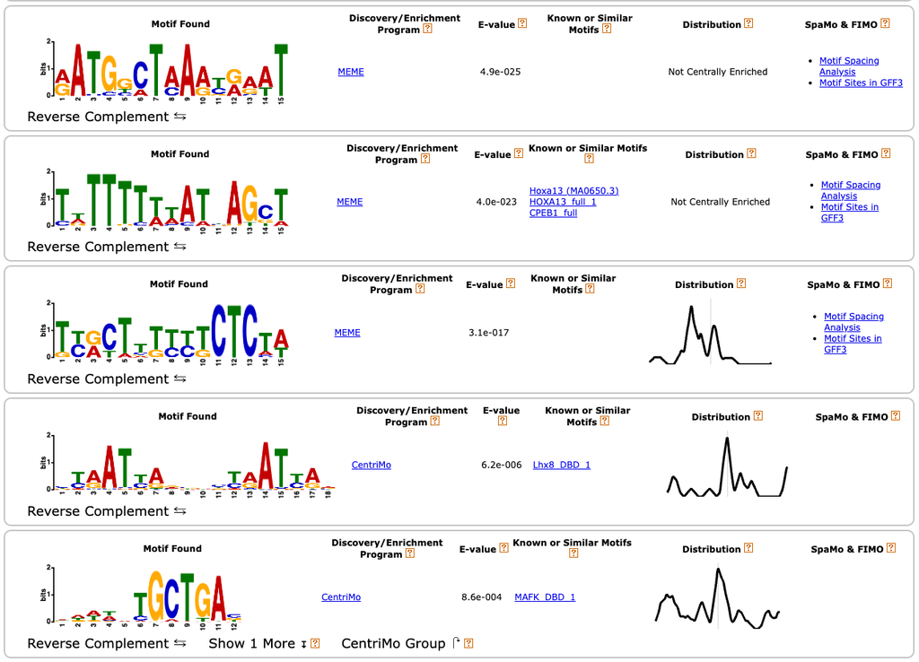

*Figure 1:* Motif logos and central enrichment analysis from MEME-ChIP. The top three motifs were discovered using MEME with highly significant E-values (as low as 4.9e-25), including one matching HOXA13 and CPEB1 binding sites. While the first two motifs were not centrally enriched, the third MEME motif and the additional motifs detected by Centrimo (e.g. matching Lhx8 and MAFK) showed clear central enrichment across ChIP-seq peaks.

The surprising finding in our analysis is that instead of the canonical Myc E-box (CACGTG, a GC-rich motif that Myc directly binds) [1], we predominantly discovered AT-rich motifs (sequences with high adenine and thymine content). This is unexpected because Myc is known to recognize and directly bind to E-box sequences in most cellular contexts. Finding different motifs suggests that in our experimental conditions, Myc may not be acting through its conventional direct DNA binding mechanism.

Central enrichment of motifs is crucial in ChIP-seq analysis because true binding sites tend to be centered within peak regions, while background or coincidental matches are randomly distributed. The fact that some non-Myc motifs show central enrichment provides strong evidence that these alternative transcription factor binding sites are functionally relevant and not statistical artifacts.

These findings suggest several potential mechanisms: (1) Myc may be recruited to DNA indirectly through protein-protein interactions with other transcription factors that recognize these AT-rich motifs, (2) Myc might be binding to non-canonical sequences [2] in this context, or (3) Myc could be part of larger multi-protein regulatory complexes. This “tethering” model, where Myc functions without directly contacting DNA, would represent a context-specific regulatory mechanism worth exploring further.

To validate these interactions, follow-up experiments could include co-immunoprecipitation to detect physical interactions between Myc and these factors, sequential ChIP to confirm co-occupancy, or reporter assays to test the functional relevance of these alternative motifs. Integrating these findings with our RNA-seq data could further reveal whether genes near these non-canonical binding sites show consistent expression patterns across our experimental conditions.

[1] Walhout AJM, Gubbels JM, Bernards R, van der Vliet PC, Timmers HTM. c-Myc/Max heterodimers bind cooperatively to the E-box sequences located in the first intron of the rat ornithine decarboxylase (ODC) gene. Nucleic Acids Res. 1997 Apr 1;25(8):1493–1501. doi:10.1093/nar/25.8.1493

[2] Sabò A, Amati B. Genome recognition by MYC. Cold Spring Harb Perspect Med. 2014 Feb 1;4(2):a014191. doi:10.1101/cshperspect.a014191. PMID: 24492846; PMCID: PMC3904094